# Random Forest

Author

Brileigh Cates

Random forest is an ensemble learning method that builds multiple decision trees and combines their predictions to improve accuracy and stability. Each tree is trained on a random subset of the data and features, and the final prediction is typically made by majority vote (for classification) or averaging (for regression). Random forest is effective because it:

- Reduces overfitting compared to individual decision trees
- Handles high-dimensional data and interactions between variables well
- Provides measures of feature importance

In this analysis, we’ll use a random forest to predict weapon-carrying behavior, leveraging its ability to handle complex, non-linear patterns and uncover influential variables that may not be obvious in simpler models.

## Setting Up the Environment

### Loading the Data

```r
analysis_data <- readRDS(here("models","data","analysis_data.rds"))
analysis_train <- readRDS(here("models","data", "analysis_train.rds"))
analysis_folds <- readRDS(here("models","data", "analysis_folds.rds"))
```

## Data Preprocessing

Before fitting our model, we need to preprocess the data. We’ll create a recipe that: - Imputes missing values in categorical variables using the mode - Imputes missing values in numeric variables using the mean - Creates dummy variables for categorical predictors

```r
weapon_carrying_forest_recipe <-
  recipe(formula = WeaponCarryingSchool ~ ., data = analysis_train) |>
  step_impute_mode(all_nominal_predictors()) |>
  step_impute_mean(all_numeric_predictors()) |>
  step_dummy(all_nominal_predictors())
```

Let’s apply our recipe to transform the data according to these preprocessing steps.

```r
weapon_carrying_forest_recipe %>%
  prep() %>%
  bake(new_data = analysis_train)
```

```
# A tibble: 14,696 × 11
   WeaponCarryingSchool AttackedInNeighborhood_X1 Bullying_X1
   <fct>                                    <dbl>       <dbl>
 1 0                                            0           0
 2 0                                            0           1
 3 0                                            0           0
 4 0                                            0           0
 5 0                                            1           0
 6 0                                            0           0
 7 0                                            0           0
 8 0                                            0           0
 9 0                                            0           0
10 0                                            1           0
# ℹ 14,686 more rows
# ℹ 8 more variables: SexualAbuseByOlderPerson_X1 <dbl>,
#   ParentalPhysicalAbuse_X1 <dbl>, ParentSubstanceUse_X1 <dbl>,
#   ParentIncarceration_X1 <dbl>, SchoolConnectedness_X1 <dbl>,
#   ParentalMonitoring_X1 <dbl>, UnfairDisciplineAtSchool_X1 <dbl>,
#   Homelessness_X1 <dbl>
```

## Model Specification

We’ll use a random forest model, which is an ensemble of decision trees trained on different random subsets of the data and predictors. This model aggregates the predictions of many trees to improve accuracy and reduce overfitting. Key hyperparameters to be tuned include mtry (the number of predictors considered at each split) and min_n (the minimum number of observations required to split a node). Random forest also provides feature importance scores, helping us identify which variables are most influential in predicting weapon carrying.

```r
weapon_carrying_forest_spec <-
  rand_forest(
    # the number of predictors to sample at each split
    mtry = tune(),
    # the number of observations needed to keep splitting nodes
    min_n = tune(),
    trees = 100) |>
  set_mode("classification") |>
  set_engine("ranger",
             # This is essential for vip()
             importance = "permutation")

weapon_carrying_forest_spec
```

```
Random Forest Model Specification (classification)

Main Arguments:
  mtry = tune()
  trees = 100
  min_n = tune()

Engine-Specific Arguments:
  importance = permutation

Computational engine: ranger
```

## Creating the Workflow

We’ll combine our recipe and model specification into a single workflow. This ensures that all preprocessing steps are properly applied during both training and prediction.

```r
weapon_carrying_forest_workflow <-
  workflow() |>
  add_recipe(weapon_carrying_forest_recipe) |>
  add_model(weapon_carrying_forest_spec)

weapon_carrying_forest_workflow
```

```
══ Workflow ════════════════════════════════════════════════════════════════════
Preprocessor: Recipe
Model: rand_forest()

── Preprocessor ────────────────────────────────────────────────────────────────
3 Recipe Steps

• step_impute_mode()
• step_impute_mean()
• step_dummy()

── Model ───────────────────────────────────────────────────────────────────────
Random Forest Model Specification (classification)

Main Arguments:
  mtry = tune()
  trees = 100
  min_n = tune()

Engine-Specific Arguments:
  importance = permutation

Computational engine: ranger
```

```r
set.seed(46257)

weapon_carrying_forest_tune <-
  tune_grid(
    weapon_carrying_forest_workflow,
    resamples = analysis_folds,
# grid = 11 says to choose 11 parameter sets automatically
    grid = 11)

collect_metrics(weapon_carrying_forest_tune)

autoplot(weapon_carrying_forest_tune)

saveRDS(weapon_carrying_forest_tune, here("models","model_outputs", "forest_tune.rds"))
```

```
# A tibble: 33 × 8
    mtry min_n .metric     .estimator   mean     n std_err .config
   <int> <int> <chr>       <chr>       <dbl> <int>   <dbl> <chr>
 1     1    17 accuracy    binary     0.957      5 0.00142 Preprocessor1_Model01
 2     1    17 brier_class binary     0.0402     5 0.00126 Preprocessor1_Model01
 3     1    17 roc_auc     binary     0.684      5 0.00987 Preprocessor1_Model01
 4     1    32 accuracy    binary     0.957      5 0.00142 Preprocessor1_Model02
 5     1    32 brier_class binary     0.0403     5 0.00125 Preprocessor1_Model02
 6     1    32 roc_auc     binary     0.685      5 0.00956 Preprocessor1_Model02
 7     2     5 accuracy    binary     0.957      5 0.00142 Preprocessor1_Model03
 8     2     5 brier_class binary     0.0400     5 0.00127 Preprocessor1_Model03
 9     2     5 roc_auc     binary     0.685      5 0.00985 Preprocessor1_Model03
10     3    21 accuracy    binary     0.957      5 0.00142 Preprocessor1_Model04
# ℹ 23 more rows
```

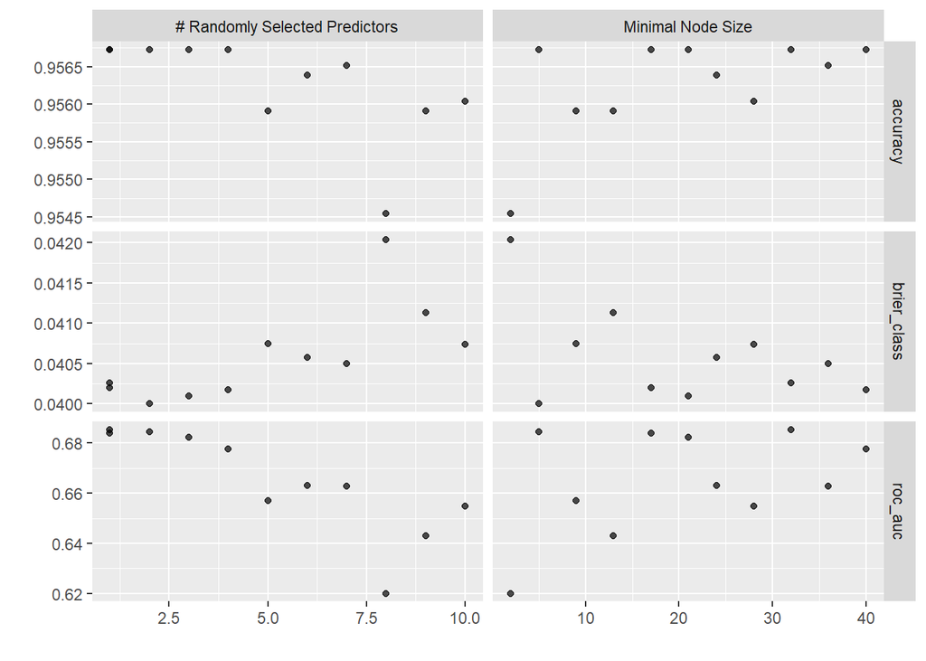

## Selecting the Best Model

We’ll select the best model based on the ROC AUC metric, which measures the model’s ability to distinguish between classes.

```r
best <- select_best(weapon_carrying_forest_tune, metric = "roc_auc")
best
```

```
# A tibble: 1 × 3
   mtry min_n .config
  <int> <int> <chr>
1     1    32 Preprocessor1_Model02
```

Now we’ll create our final workflow with the best hyperparameters.

```r
final_wf <- finalize_workflow(weapon_carrying_forest_workflow, best)

final_wf
```

```
══ Workflow ════════════════════════════════════════════════════════════════════
Preprocessor: Recipe
Model: rand_forest()

── Preprocessor ────────────────────────────────────────────────────────────────
3 Recipe Steps

• step_impute_mode()
• step_impute_mean()
• step_dummy()

── Model ───────────────────────────────────────────────────────────────────────
Random Forest Model Specification (classification)

Main Arguments:
  mtry = 1
  trees = 100
  min_n = 32

Engine-Specific Arguments:
  importance = permutation

Computational engine: ranger
```

## Fitting the Final Model

We’ll fit our final model on the training data. This process is also time-consuming, so we’ll save the results.

```r
weapon_carrying_forest_fit <- fit(final_wf, analysis_train)

saveRDS(weapon_carrying_forest_fit, here("models","model_outputs", "forest_fit.rds"))
```

## Model Evaluation

Let’s examine the model’s predictions on the training data.

```r
forest_pred <-
  augment(weapon_carrying_forest_fit, analysis_train) |>
  select(WeaponCarryingSchool, .pred_class, .pred_1, .pred_0)

forest_pred
```

```
# A tibble: 14,696 × 4
   WeaponCarryingSchool .pred_class .pred_1 .pred_0
   <fct>                <fct>         <dbl>   <dbl>
 1 0                    0            0.0465   0.953
 2 0                    0            0.0416   0.958
 3 0                    0            0.0335   0.967
 4 0                    0            0.0397   0.960
 5 0                    0            0.105    0.895
 6 0                    0            0.0465   0.953
 7 0                    0            0.0308   0.969
 8 0                    0            0.0308   0.969
 9 0                    0            0.0489   0.951
10 0                    0            0.0465   0.954
# ℹ 14,686 more rows
```

We can visualize the model’s performance using an ROC curve.

```r
roc_forest <-
  forest_pred |>
  roc_curve(truth = WeaponCarryingSchool,
           .pred_1,
           event_level = "second") |>
  autoplot()

roc_forest

saveRDS(roc_forest, here("models","roc_graphs","forest.rds"))

forest_pred |>
  roc_auc(truth = WeaponCarryingSchool,
           .pred_1,
           event_level = "second")
```

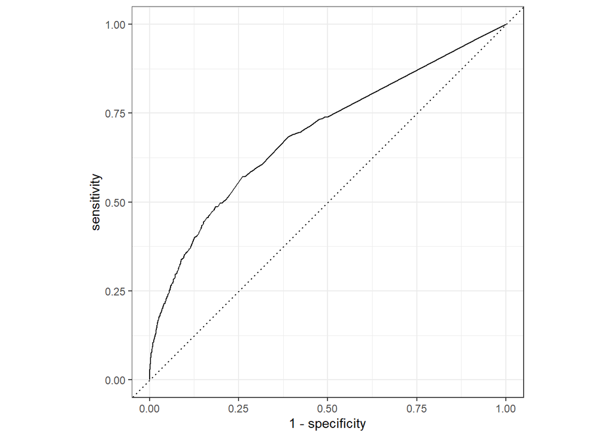

```r
#echo: false

roc_forest <- readRDS(here("models","roc_graphs","forest.rds"))

roc_forest
```

## Cross-Validation Results

We’ll fit the model on each cross-validation fold to get a more robust estimate of its performance.

```r
fit_resamples(final_wf, resamples = analysis_folds) |>
  collect_metrics()
```

```
# A tibble: 3 × 6
  .metric     .estimator   mean     n std_err .config
  <chr>       <chr>       <dbl> <int>   <dbl> <chr>
1 accuracy    binary     0.957      5 0.00142 Preprocessor1_Model1
2 brier_class binary     0.0402     5 0.00125 Preprocessor1_Model1
3 roc_auc     binary     0.686      5 0.0103  Preprocessor1_Model1
```